# Cao_Jinpu_A6

## 1. A Map of San Francisco PUMAs

[interactive chart not shown]

## 2. Then grab PUMS data for these PUMAs.

## 3. Filter to housing structures built before 1960.

## 4. Create a Variable - Leadrisk

## 5. Logit Model: leadrisk ~ BLD, TEN, MV, and PUMA

summary(logit_model)

```
##
## Call:
## glm(formula = leadrisk ~ BLD_f + TEN_f + MV_f + PUMA_f, family = quasibinomial(),
##     data = sf_pums_5)
##
## Deviance Residuals:
##     Min       1Q   Median       3Q      Max
## -0.8632  -0.1914  -0.1263  -0.0661   3.2242
##
## Coefficients:
##               Estimate Std. Error t value Pr(>|t|)
## (Intercept) -2.274e+01  1.038e+04  -0.002  0.99825
## BLD_f2       1.754e+01  1.038e+04   0.002  0.99865
## BLD_f3       1.672e+01  1.038e+04   0.002  0.99871
## BLD_f4       1.647e+01  1.038e+04   0.002  0.99873
## BLD_f5       1.631e+01  1.038e+04   0.002  0.99875
## BLD_f6       1.671e+01  1.038e+04   0.002  0.99872
## BLD_f7       2.441e-01  1.043e+04   0.000  0.99998
## BLD_f8       3.035e-01  1.043e+04   0.000  0.99998
## BLD_f9       1.646e+01  1.038e+04   0.002  0.99873
## BLD_f10      4.766e-01  1.810e+04   0.000  0.99998
## TEN_f2      -2.537e-01  5.073e-01  -0.500  0.61711
## TEN_f3       8.810e-01  3.734e-01   2.360  0.01838 *
## TEN_f4       1.427e+00  7.181e-01   1.986  0.04710 *
## MV_f2       -5.253e-03  7.837e-01  -0.007  0.99465
## MV_f3        8.266e-01  5.695e-01   1.451  0.14680
## MV_f4        7.609e-01  5.712e-01   1.332  0.18302
## MV_f5       -1.922e-01  6.372e-01  -0.302  0.76296
## MV_f6       -1.173e-01  6.678e-01  -0.176  0.86064
## MV_f7       -6.513e-01  7.291e-01  -0.893  0.37180
## PUMA_f07502  8.144e-01  7.748e-01   1.051  0.29332
## PUMA_f07503  5.656e-01  8.617e-01   0.656  0.51164
## PUMA_f07504  1.384e+00  6.787e-01   2.039  0.04162 *
## PUMA_f07505  1.307e-01  8.497e-01   0.154  0.87780
## PUMA_f07506  1.955e+00  6.695e-01   2.920  0.00354 **
## PUMA_f07507  2.146e+00  6.816e-01   3.148  0.00166 **
## ---
## Signif. codes:  0 '***' 0.001 '**' 0.01 '*' 0.05 '.' 0.1 ' ' 1
##
## (Dispersion parameter for quasibinomial family taken to be 0.6997084)
##
##     Null deviance: 377.83  on 2263  degrees of freedom
## Residual deviance: 320.38  on 2239  degrees of freedom
## AIC: NA
##
## Number of Fisher Scoring iterations: 19
```

make a prediction

```
## # A tibble: 1 x 5
##     YBL TEN   MV    PUMA  leadrisk
##   <dbl> <chr> <chr> <chr>    <dbl>
## 1     2 2     6     07507        0
```

```
##          1
## 0.03169584
```

## 6. Predicted Score (threshold = 0.1)

```
##
## .                FALSE TRUE
##   No (safe)       2200   27
##   Yes (leadrisk)    33    4
```

predicted score = (2200 + 4) / (2200 + 27 + 33 + 4) = 97.35%  
true positives: 4  
true negatives: 2200  
Type 1 errors: 27  
Type 2 errors: 33  
Type 1/2 errors: 27 / 33 = 0.8182  
**Describe the households which exceeded your threshold score in simple heuristics (i.e., what values did they generally have for BLD, TEN, and MV, in plain English).**  
The following charts are the histograms of BLD, TEN, and MV of the households which exceeded the threshold score 0.1. From the charts we can see that these households generally have 2 (One-family house detached) for BLD, 3 and 4 (Rented, Occupied without payment of rent) for TEN, 3 and 4 (2 to 9 years) for MV.

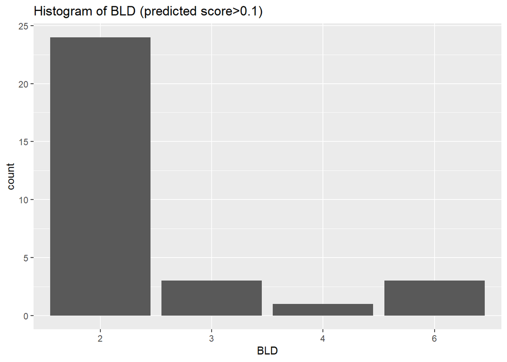

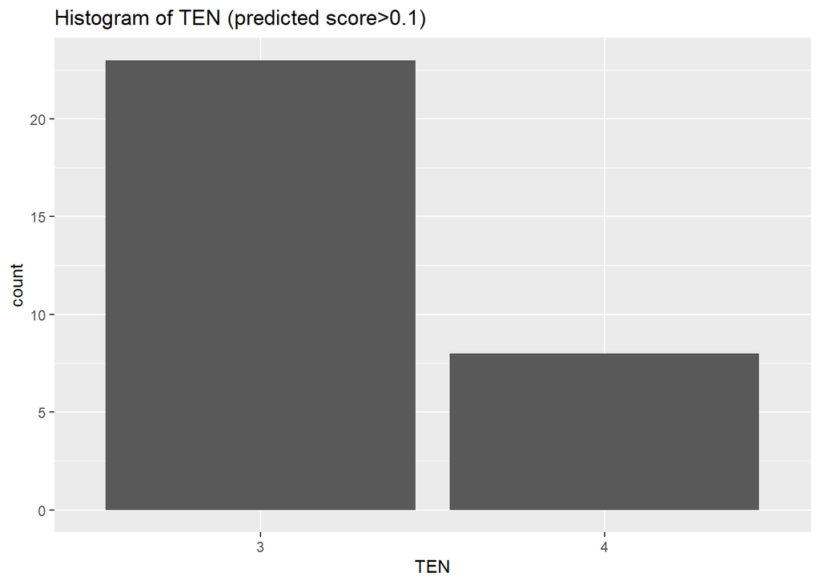

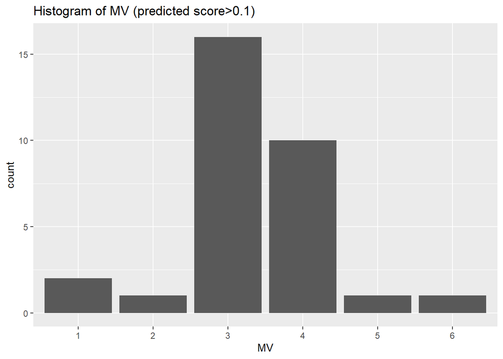

**Comment on the success rate expected if the organization were to mail postcards to households of this type:**  
**Roughly how many would they mail out based on their threshold score?**  
They would mail out 31 (4+27) test kits based on their threshold score.  
**What percentage of postcards do you expect to actually go to low-income households with children?**  
4 / (4 + 27) = 12.9%  
**What percentage of all at-risk children are likely to be reached?**  
4 / (4 + 33) = 10.8%  
**Discuss ways you might improve your strategy, assuming you don’t directly have access to information about incomes and presence of children at the address level.**  
We can use more related variables (feature engineering) for regression. And also we can lower the threshold score, such as 0.05, to reduce the false negatives.

## 7. Replicate Weights

summary(logit_survey_model)

```
##
## Call:
## svyglm(formula = leadrisk ~ BLD_f + TEN_f + MV_f + PUMA_f, family = quasibinomial(),
##     design = logit_survey_design)
##
## Survey design:
## svrepdesign.default(data = sf_pums_5, type = "ACS", repweights = pums_2019_1yr_wts,
##     weights = ~as.numeric(WGTP))
##
## Coefficients:
##              Estimate Std. Error t value Pr(>|t|)
## (Intercept) -23.31748    1.93703 -12.038  < 2e-16 ***
## BLD_f2       16.93981    1.12522  15.055  < 2e-16 ***
## BLD_f3       15.97097    1.24785  12.799  < 2e-16 ***
## BLD_f4       15.37557    1.40713  10.927 2.12e-15 ***
## BLD_f5       16.86506    1.22116  13.811  < 2e-16 ***
## BLD_f6       16.40956    1.39906  11.729  < 2e-16 ***
## BLD_f7       -0.06112    0.66803  -0.091  0.92743
## BLD_f8       -0.05429    0.76859  -0.071  0.94395
## BLD_f9       15.48515    1.50682  10.277 2.08e-14 ***
## BLD_f10       0.55758    0.91261   0.611  0.54373
## TEN_f2       -0.60798    0.69836  -0.871  0.38777
## TEN_f3        0.81482    0.45856   1.777  0.08111 .
## TEN_f4        0.60506    1.21876   0.496  0.62155
## MV_f2         0.03890    1.08981   0.036  0.97165
## MV_f3         1.02945    0.71536   1.439  0.15580
## MV_f4         1.05802    0.85943   1.231  0.22354
## MV_f5        -0.12039    0.95756  -0.126  0.90041
## MV_f6         0.18477    1.02810   0.180  0.85803
## MV_f7        -0.61423    1.11953  -0.549  0.58547
## PUMA_f07502   0.93364    1.24197   0.752  0.45541
## PUMA_f07503   1.63919    1.31440   1.247  0.21764
## PUMA_f07504   2.49902    1.03791   2.408  0.01943 *
## PUMA_f07505   1.48155    1.28782   1.150  0.25494
## PUMA_f07506   3.25593    1.08586   2.998  0.00407 **
## PUMA_f07507   3.53744    1.08485   3.261  0.00191 **
## ---
## Signif. codes:  0 '***' 0.001 '**' 0.01 '*' 0.05 '.' 0.1 ' ' 1
##
## (Dispersion parameter for quasibinomial family taken to be 1799.432)
##
## Number of Fisher Scoring iterations: 19
```

predict a sample

```
## # A tibble: 1 x 5
##     YBL TEN   MV    PUMA  leadrisk
##   <dbl> <chr> <chr> <chr>    <dbl>
## 1     1 1     6     07501        0
```

```
##     response    SE
## 1 0.00042749 5e-04
```

summary_2x2

```
##
## .                FALSE TRUE
##   No (safe)       2129   98
##   Yes (leadrisk)    26   11
```

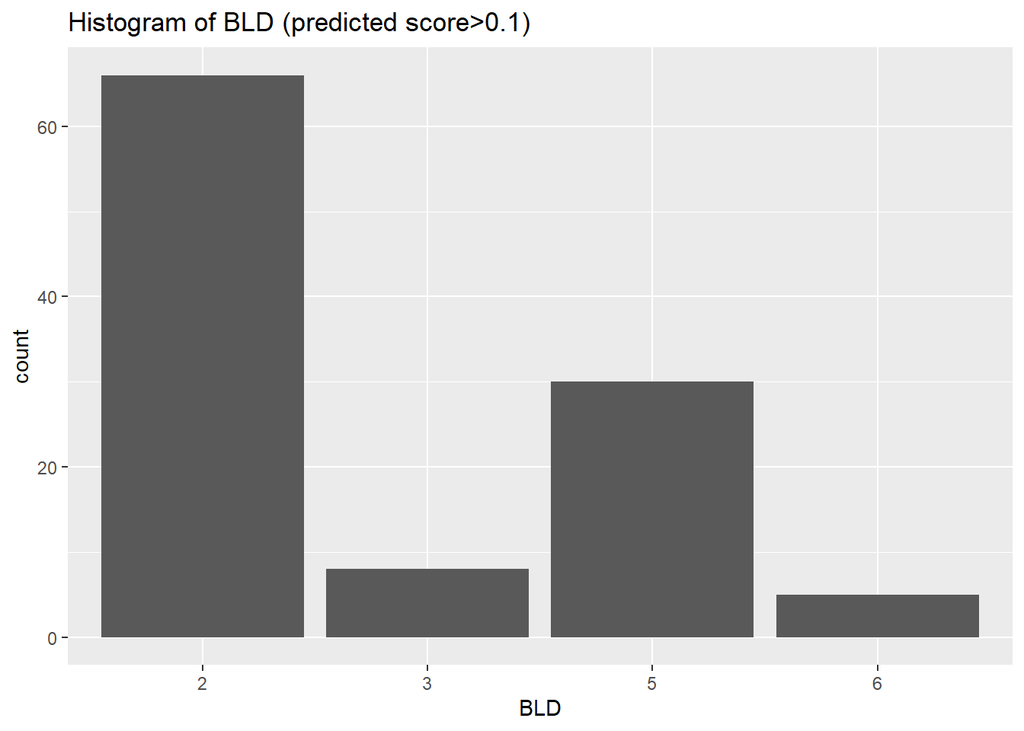

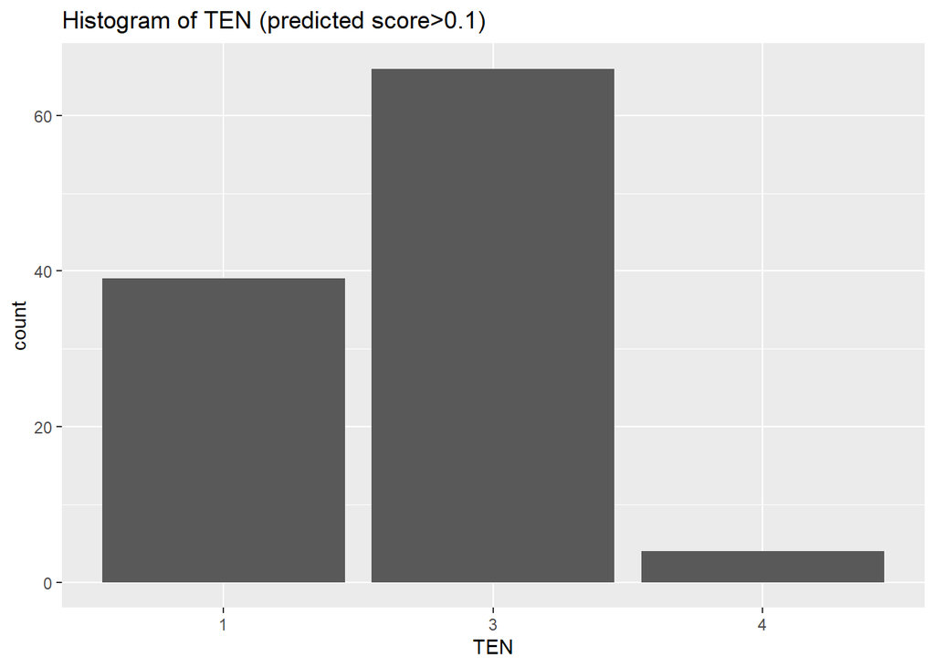

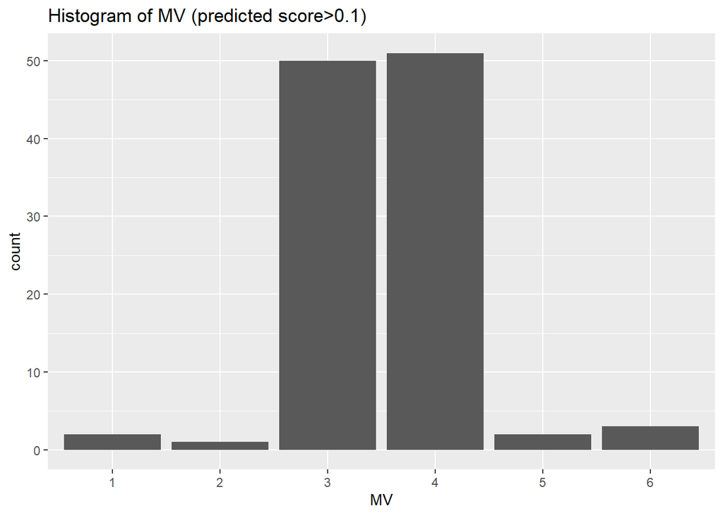

**Comment on the success rate expected if the organization were to mail postcards to households of this type:**  
**Roughly how many would they mail out based on their threshold score?**  
They would mail out 109 (98+11) test kits based on their threshold score.  
**What percentage of postcards do you expect to actually go to low-income households with children?**  
11 / (11 + 98) = 10.1%  
**What percentage of all at-risk children are likely to be reached?**  
11 / (11 + 26) = 29.7%